# 晓松

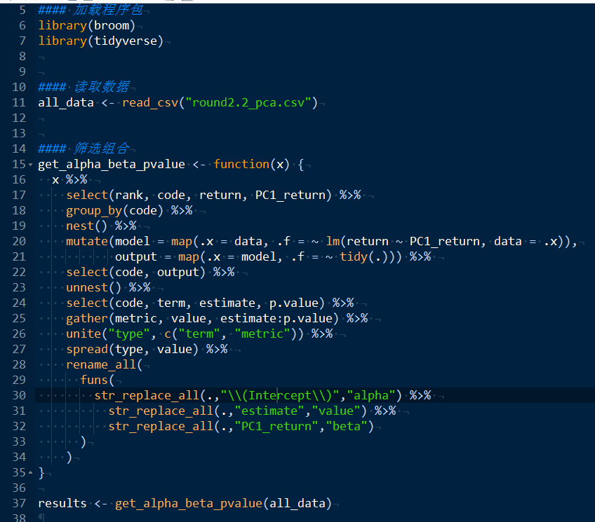

这里未加入时间限制，但是其实也非常简单，只要加入`filter()`，中间限制`rank`即可。 例如

```r
x %>%
  select(rank,code,return) %>%
  filter(rank > 343, rank < 353)
```

但是我感觉`get_alpha_beta_pvalue`这个函数进行了更新，你可以参考现在最新的函数，

地址: http://p24kaozv6.bkt.clouddn.com/fcontest_output17.html 书签: 2.7.3.3 α,β,p value

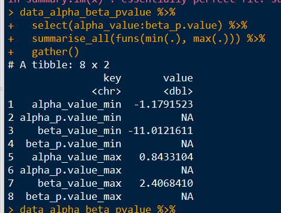

> 还有就是我使用你的get_alpha_beta_pvalue的方法，在加入期数的限制（343-353）得到的结果是下图这样的 ，还需要平移吗？

我没有看懂平移的意思，但是我觉得这个函数似乎报错了，p value都是空值，这应该不对，你可以先把你的`data_alpha_beta_pvalue` 提取出来，看看缺失率。

> 我没有对其进行平移 然后最后挑选的结果与之前我给你提到的“不重复数据”的股票组选择一样

> 但是始终没有解决掉 为啥和“重复数据”结果不同的问题 哈哈

重复数据这点我没有看懂，你可以解释一下吗？

## 平移转换

```r
a <- -0.9
b <- 0.8

a^b
```

```
## [1] NaN
```

```r
# 处理方式一
abs(a)^b*ifelse(a > 0, 1,-1)
```

```
## [1] -0.9191661
```

```r
# 处理方式二

(a+2)^b
```

```
## [1] 1.07923
```

## 重复问题

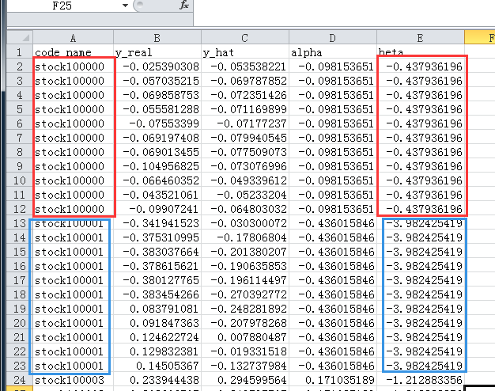

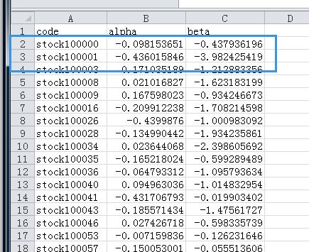

晓松根据你给我的这两个图，其实他们是一回事。

因为一个回归方程，

$$y = \beta_0 + \beta_1 x + \mu$$

假设， $y: [y_1,y_2,\cdots,y_{30}]$ $x: [x_1,x_2,\cdots,x_{30}]$

我们一定会得到

$\hat y: [\hat y_1,\hat y_2,\cdots,\hat y_{30}]$

但是只有一个$\hat \beta_0$和$\hat \beta_1$，因此你会看到重复值，但是都不矛盾的，

我建议你对重复值的图做这个处理，`distinct(everything())`，理论上你会得到两个一样的结果。 你可以用`setequal`进行验证。

# 武神

我看了下`makeMeasure`函数的参数，暂时没找到对$\beta$进行约束的方法（可能我没有认真看明白），这个你之前直接构建过lasso或者ridge的损失函数吗？ 我觉得我的自定义函数，需要考虑对$\beta$进行约束，这个是一般R包的难点。

参考链接:

- [makeMeasure function | R Documentation](https://www.rdocumentation.org/packages/mlr/versions/2.12.1/topics/makeMeasure)
- [Create Custom Measures - mlr tutorial](https://mlr-org.github.io/mlr-tutorial/release/html/create_measure/index.html)